# R Notebook

Miguel Albertí Pons &Iker González Cuellar

09-01-23

## Ejercicio 1

**Enumere cuales son las hipótesis que asumimos al hacer una regresión múltiple entre una variable de respuesta y y unas variables predictoras, x1, …, xp.**

- En el modelo de regresión lineal múltiple se supone que la función de regresión que relaciona la variable dependiente con las variables independientes es lineal.
- Asumimos que los errores ε1, ε2, . . . , εn tienen distribución normal de media cero y varianza σ2, y que son independientes.
- Las variables explicativas son linealmente independientes entre si.

## Ejercicio 2

**En un modelo de regresión, como se calcula y como se interpreta el coeficiente de determinación R2.**

R2 se interpreta como un coeficiente o proporcion de la variabilidad de la variable de respuesta explicada por el modelo (en otras palabras, que tanto explica el vector de ajuste al vector respuesta).

Valores de R que se aproximen a:

- 1 indican ajustes perfectos,
- entre 0.4 y 0.7 son ajustes medianos
- menores a 0.4 son ajustes bajos
- cercanos a 0 son inservibles.

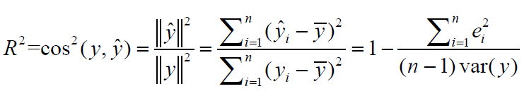

## Ejercicio 3

**Lea el fichero “BCN_pisos.txt”. Del fichero resultante seleccione 2/3 partes como muestra de training y la tercera parte restante como muestra test.**

```r
pisos_bcn = read.delim("bcn_pisos.txt")
length = nrow(pisos_bcn)
number_training_rows =  round(length / 3) * 2

training = pisos_bcn[0:number_training_rows,]
test = pisos_bcn[number_training_rows:length-1,]
```

## Ejercicio 4

**Con la muestra de training, efectúe la representación gráfica de la variable “Valor” respecto del resto de variables del fichero. Calcule la correlación entre la variable “Valor” y el resto de variables numéricas.**

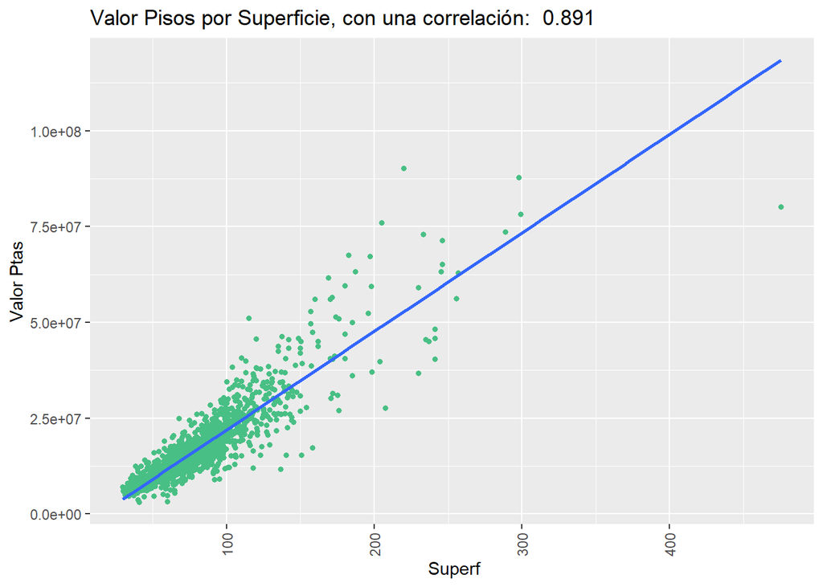

```r
library(ggplot2)

colorPalett = c("#99E47E", "#48BF84", "#439775", "#3C7A80", "#D65F65")
correlation = round(cor(training$Valor, training$Superf),3)
value_vs_super = ggplot(training, aes(y = Valor, x = Superf, group = 1)) + geom_point(color = "#48BF84", size =1.2) + geom_smooth(method='lm', se = FALSE) + theme(axis.text.x = element_text(angle = 90, vjust = 0.5, hjust=1)) + ggtitle(paste("Valor Pisos por Superficie, con una correlación: ", correlation)) + labs(y = "Valor Ptas", x = " Superf") + scale_fill_manual(values=colorPalett)
print(value_vs_super)
```

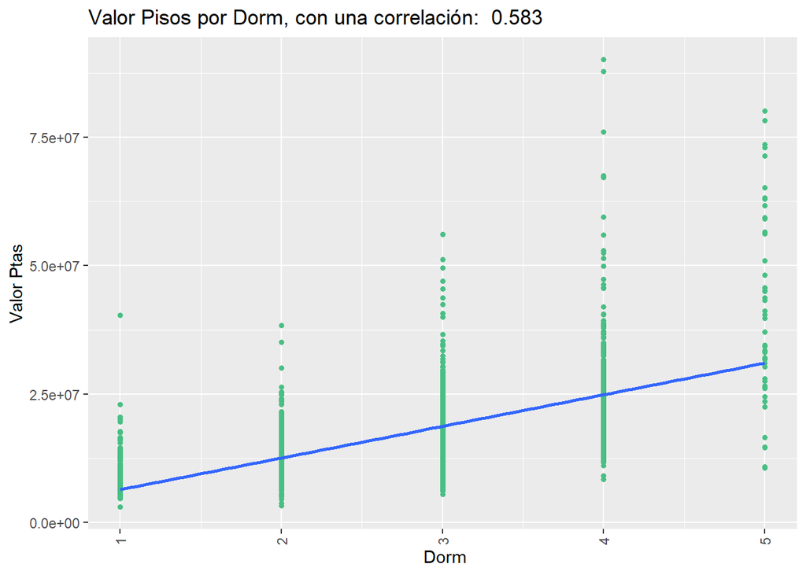

```r
correlation = round(cor(training$Valor, training$Dorm),3)
value_vs_dorm = ggplot(training, aes(y = Valor, x = Dorm, group = 1)) + geom_point(color = "#48BF84", size =1.2) + geom_smooth(method='lm', se = FALSE) + theme(axis.text.x = element_text(angle = 90, vjust = 0.5, hjust=1)) + ggtitle(paste("Valor Pisos por Dorm, con una correlación: ", correlation)) + labs(y = "Valor Ptas", x = " Dorm") + scale_fill_manual(values=colorPalett)
print(value_vs_dorm)
```

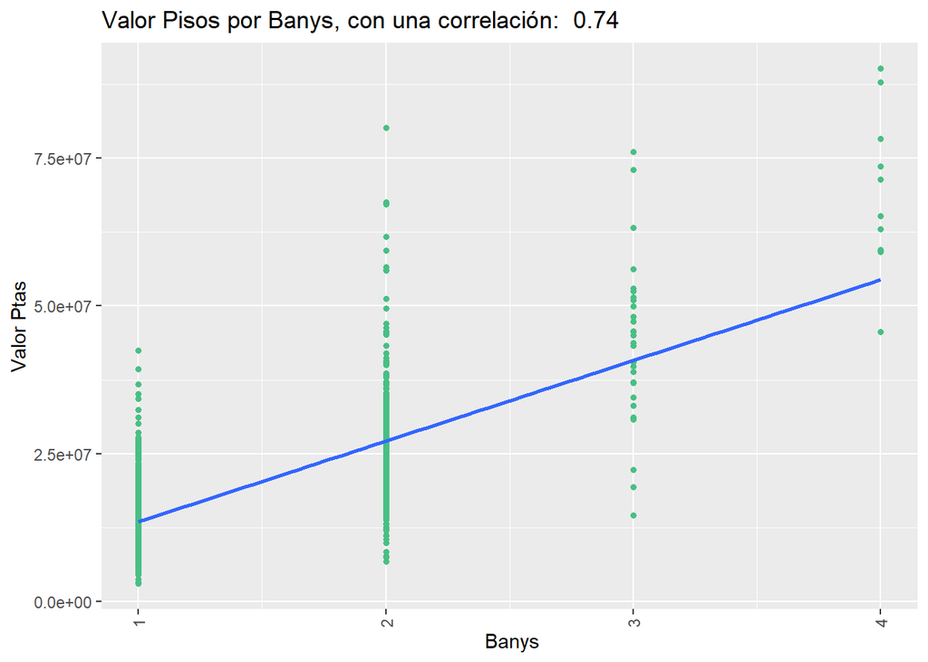

```r
correlation = round(cor(training$Valor, training$Banys),3)
value_vs_banys = ggplot(training, aes(y = Valor, x = Banys, group = 1)) + geom_point(color = "#48BF84", size =1.2) + geom_smooth(method='lm', se = FALSE) + theme(axis.text.x = element_text(angle = 90, vjust = 0.5, hjust=1)) + ggtitle(paste("Valor Pisos por Banys, con una correlación: ", correlation)) + labs(y = "Valor Ptas", x = " Banys") + scale_fill_manual(values=colorPalett)
print(value_vs_banys)
```

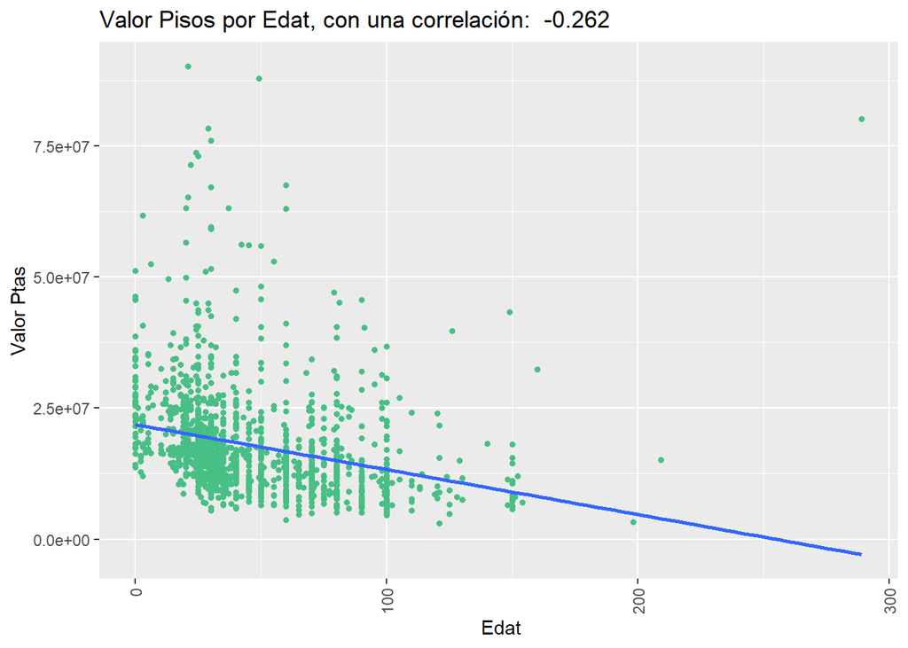

```r
correlation = round(cor(training$Valor, training$Edat),3)
value_vs_edat = ggplot(training, aes(y = Valor, x = Edat, group = 1)) + geom_point(color = "#48BF84", size =1.2) + geom_smooth(method='lm', se = FALSE) + theme(axis.text.x = element_text(angle = 90, vjust = 0.5, hjust=1)) + ggtitle(paste("Valor Pisos por Edat, con una correlación: ", correlation)) + labs(y = "Valor Ptas", x = " Edat") + scale_fill_manual(values=colorPalett)
print(value_vs_edat)
```

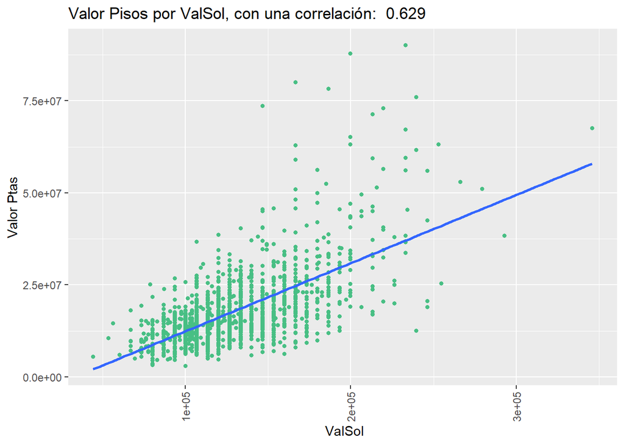

```r
correlation = round(cor(training$Valor, training$ValSol),3)
value_vs_valsol = ggplot(training, aes(y = Valor, x = ValSol, group = 1)) + geom_point(color = "#48BF84", size =1.2) + geom_smooth(method='lm', se = FALSE) + theme(axis.text.x = element_text(angle = 90, vjust = 0.5, hjust=1)) + ggtitle(paste("Valor Pisos por ValSol, con una correlación: ", correlation)) + labs(y = "Valor Ptas", x = " ValSol") + scale_fill_manual(values=colorPalett)
print(value_vs_valsol)
```

Aunque al realizar la representación gráfica, ya hemos visto la **cor** del valor con su respectiva variable, ahora realizaremos una tabla comparativa de correlaciones.

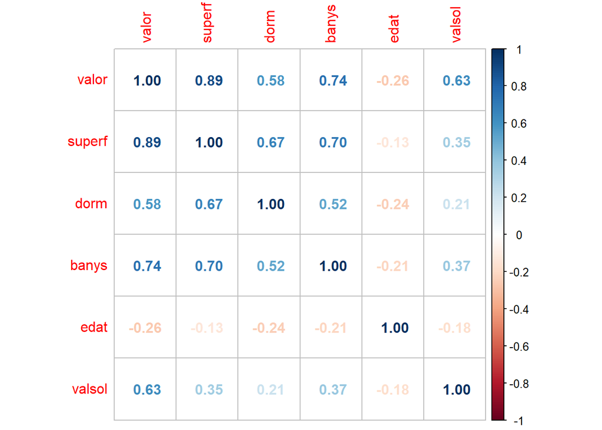

```r
library(corrplot)
df_numeric_variables = data.frame('valor' = training$Valor,
                                  'superf' = training$Superf,
                                  'dorm' = training$Dorm,
                                  'banys' = training$Banys,
                                  'edat' = training$Edat,
                                  'valsol' = training$ValSol)
R = cor(df_numeric_variables)
corrplot(R,method='number')
```

## Ejercicio 5

**Efectúe la regresión simple de la variable “Valor” respecto de la “Superficie”. A continuación añada a la regresión la variable “Número de dormitorios”. Es significativa esta variable una vez que el modelo ya contiene la variable “Superficie”.**

```r
regval_super = lm(training$Valor ~ training$Superf, training)
regval_super_dorm = lm(training$Valor ~ training$Super + training$Dorm, training)
summary = summary(regval_super_dorm)
anova = anova(regval_super_dorm)
summary
```

```
##
## Call:
## lm(formula = training$Valor ~ training$Super + training$Dorm,
##     data = training)
##
## Residuals:
##       Min        1Q    Median        3Q       Max
## -39576915  -2204364   -325563   1906411  37065352
##
## Coefficients:
##                Estimate Std. Error t value Pr(>|t|)
## (Intercept)    -3477186     375265  -9.266   <2e-16 ***
## training$Super   261684       4483  58.367   <2e-16 ***
## training$Dorm   -239684     164233  -1.459    0.145
## ---
## Signif. codes:  0 '***' 0.001 '**' 0.01 '*' 0.05 '.' 0.1 ' ' 1
##
## Residual standard error: 4642000 on 1549 degrees of freedom
## Multiple R-squared:  0.7936, Adjusted R-squared:  0.7933
## F-statistic:  2977 on 2 and 1549 DF,  p-value: < 2.2e-16
```

Podemos observar que la variable Dorm tiene un valor muy negativo -239684, además el p-value es de 0.145, por tanto podemos deducir que no, no es una variable significativa.

```r
anova
```

|  | Df | Sum Sq | Mean Sq | F value | Pr(>F) |
| --- | --- | --- | --- | --- | --- |
| training$Super | 1 | 1.282614e+17 | 1.282614e+17 | 5952.322887 | 0.0000000 |
| training$Dorm | 1 | 4.589541e+13 | 4.589541e+13 | 2.129902 | 0.1446527 |
| Residuals | 1549 | 3.337805e+16 | 2.154813e+13 | NA | NA |

Realizando el test anova confirma lo que habiamos dicho, con un p_value de 0.1447 podemos decir que la variable no es significativa.

## Ejercicio 6

**Efectúe la regresión múltiple del “Valor” respecto el resto de variables del fichero “BCN_pisos”.¿Le parece que alguna variable predictora es no significativa?.**

```r
reg = lm(training$Valor~.,training)
summary(reg)
```

```
##
## Call:
## lm(formula = training$Valor ~ ., data = training)
##
## Residuals:
##       Min        1Q    Median        3Q       Max
## -15657097  -1072750     96817   1182167  28476613
##
## Coefficients:
##                     Estimate Std. Error t value Pr(>|t|)
## (Intercept)       -1.192e+07  1.149e+06 -10.374  < 2e-16 ***
## Superf             2.030e+05  3.001e+03  67.647  < 2e-16 ***
## Dorm              -1.188e+05  9.418e+04  -1.262 0.207297
## Banys              1.688e+06  1.691e+05   9.983  < 2e-16 ***
## Edat              -1.886e+04  3.218e+03  -5.860 5.66e-09 ***
## Estat2_M           1.246e+06  1.983e+05   6.284 4.31e-10 ***
## Estat3_N           2.176e+06  2.150e+05  10.122  < 2e-16 ***
## Estat4_B           3.323e+06  2.763e+05  12.028  < 2e-16 ***
## Estat5_MB          2.676e+06  4.852e+05   5.516 4.07e-08 ***
## PlantaBajos       -8.461e+05  3.604e+05  -2.348 0.019025 *
## PlantaPlanta      -5.572e+05  2.111e+05  -2.640 0.008374 **
## DistEixample      -8.768e+05  2.706e+05  -3.240 0.001219 **
## DistGracia        -1.087e+06  2.982e+05  -3.644 0.000277 ***
## DistHorta         -1.212e+06  4.203e+05  -2.885 0.003973 **
## DistLes_Corts      2.666e+05  5.719e+05   0.466 0.641184
## DistNou_Barris    -7.847e+05  3.580e+05  -2.192 0.028562 *
## DistSant_Andreu   -8.530e+05  3.525e+05  -2.420 0.015639 *
## DistSant_Marti    -1.047e+06  2.639e+05  -3.968 7.60e-05 ***
## DistSants         -8.555e+05  2.811e+05  -3.043 0.002380 **
## DistSarria         8.970e+05  3.760e+05   2.386 0.017163 *
## ValSol             9.292e+01  2.582e+00  35.987  < 2e-16 ***
## TipusMANZ         -1.167e+06  2.547e+05  -4.581 5.00e-06 ***
## AscensSI          -7.014e+04  1.664e+05  -0.422 0.673359
## ExtIntINT          5.497e+05  1.855e+05   2.963 0.003092 **
## ReformaOBRANUEVA   2.665e+06  1.140e+06   2.338 0.019512 *
## ReformaRECIENREF   1.348e+05  1.034e+06   0.130 0.896235
## ReformaREF>20      3.003e+05  1.055e+06   0.285 0.775996
## ReformaREF10-15    1.794e+05  1.038e+06   0.173 0.862836
## ReformaREF15-20    1.931e+05  1.063e+06   0.182 0.855902
## ReformaREF1A5      3.166e+05  1.020e+06   0.310 0.756291
## ReformaREF5A10     4.616e+05  1.028e+06   0.449 0.653331
## ReformaSINREFORMA -4.704e+05  1.020e+06  -0.461 0.644714
## ---
## Signif. codes:  0 '***' 0.001 '**' 0.01 '*' 0.05 '.' 0.1 ' ' 1
##
## Residual standard error: 2446000 on 1520 degrees of freedom
## Multiple R-squared:  0.9438, Adjusted R-squared:  0.9426
## F-statistic:   823 on 31 and 1520 DF,  p-value: < 2.2e-16
```

```r
anova(reg)
```

|  | Df | Sum Sq | Mean Sq | F value | Pr(>F) |
| --- | --- | --- | --- | --- | --- |
| Superf | 1 | 1.282614e+17 | 1.282614e+17 | 2.144520e+04 | 0.000000e+00 |
| Dorm | 1 | 4.589541e+13 | 4.589541e+13 | 7.673672e+00 | 5.671413e-03 |
| Banys | 1 | 4.280979e+15 | 4.280979e+15 | 7.157759e+02 | 1.560656e-129 |
| Edat | 1 | 2.739126e+15 | 2.739126e+15 | 4.579795e+02 | 5.014951e-89 |
| Estat | 4 | 2.220743e+15 | 5.551858e+14 | 9.282658e+01 | 1.093418e-70 |
| Planta | 2 | 8.776343e+13 | 4.388172e+13 | 7.336985e+00 | 6.743269e-04 |
| Dist | 9 | 6.974277e+15 | 7.749197e+14 | 1.295659e+02 | 6.684687e-181 |
| ValSol | 1 | 7.515800e+15 | 7.515800e+15 | 1.256635e+03 | 4.069855e-201 |
| Tipus | 1 | 1.304623e+14 | 1.304623e+14 | 2.181319e+01 | 3.270335e-06 |
| Ascens | 1 | 6.905935e+11 | 6.905935e+11 | 1.154666e-01 | 7.340512e-01 |

[output cut: 3 more lines]

## Ejercicio 7

**Encuentre la regresión óptima. ¿Cuál es el valor del R2 alcanzado?. ¿Y cuál el valor del R2 por validación cruzada “leave one out”?**

```r
library(olsrr)
bestval = ols_step_best_subset(reg)
bestval
```

|  | mindex | n | predictors | rsquare | adjr | predrsq | cp | aic | sbic | sbc | msep | fpe | apc | hsp |
| --- | --- | --- | --- | --- | --- | --- | --- | --- | --- | --- | --- | --- | --- | --- |
| 1 | 1 | 1 | Superf | 0.7932778 | 0.7931445 | 0.7902386 | 4040.454262 | 52057.95 | 47649.63 | 52073.99 | 3.346707e+16 | 2.159162e+13 | 0.20725563 | 13921133293 |
| 19 | 2 | 2 | Superf ValSol | 0.9094958 | 0.9093790 | 0.9075363 | 900.658349 | 50778.03 | 46371.18 | 50799.42 | 1.466155e+16 | 9.465130e+12 | 0.09085475 | 6102628904 |
| 108 | 3 | 3 | Superf Estat ValSol | 0.9308361 | 0.9305675 | 0.9286889 | 325.752701 | 50368.67 | 45956.87 | 50411.45 | 1.121170e+16 | 7.256707e+12 | 0.06952134 | 4678766576 |
| 354 | 4 | 4 | Superf Banys Estat ValSol | 0.9362717 | 0.9359827 | 0.9340756 | 180.809356 | 50243.64 | 45832.24 | 50291.76 | 1.033725e+16 | 6.695035e+12 | 0.06414028 | 4316646083 |
| 948 | 5 | 5 | Superf Banys Estat Dist ValSol | 0.9388708 | 0.9382337 | 0.9360173 | 112.544304 | 50197.01 | 45769.89 | 50293.26 | 9.922065e+15 | 6.463779e+12 | 0.06160364 | 4167563778 |
| 1802 | 6 | 6 | Superf Banys Edat Estat Dist ValSol | 0.9405799 | 0.9399214 | 0.9377586 | 68.343415 | 50155.00 | 45728.14 | 50256.60 | 9.650916e+15 | 6.291199e+12 | 0.05995858 | 4056315701 |
| 2780 | 7 | 7 | Superf Banys Edat Estat Dist ValSol Reforma | 0.9424248 | 0.9414816 | 0.9389747 | 20.466466 | 50122.05 | 45681.62 | 50266.43 | 9.357316e+15 | 6.131746e+12 | 0.05817178 | 3953532521 |
| 3534 | 8 | 8 | Superf Banys Edat Estat Dist ValSol Tipus Reforma | 0.9430809 | 0.9421105 | 0.9395353 | 4.729750 | 50106.26 | 45666.03 | 50255.99 | 9.256684e+15 | 6.069735e+12 | 0.05758305 | 3913579316 |
| 3934 | 9 | 9 | Superf Banys Edat Estat Dist ValSol Tipus ExtInt Reforma | 0.9433803 | 0.9423772 | 0.9397756 | -1.362510 | 50100.08 | 45659.97 | 50255.15 | 9.213978e+15 | 6.045646e+12 | 0.05735408 | 3898079997 |
| 4064 | 10 | 10 | Superf Banys Edat Estat Planta Dist ValSol Tipus ExtInt Reforma | 0.9437075 | 0.9426349 | 0.9399373 | -8.208662 | 50095.08 | 45653.13 | 50260.85 | 9.166675e+15 | 6.022457e+12 | 0.05709614 | 3883164077 |

[output cut: 2 more lines]

```r
reg = lm(training$Valor~.,training)
setepval = step(reg)
```

```
## Start:  AIC=45690.87
## training$Valor ~ Superf + Dorm + Banys + Edat + Estat + Planta +
##     Dist + ValSol + Tipus + Ascens + ExtInt + Reforma
##
##           Df  Sum of Sq        RSS   AIC
## - Ascens   1 1.0632e+12 9.0920e+15 45689
## - Dorm     1 9.5189e+12 9.1005e+15 45690
## <none>                  9.0910e+15 45691
## - Planta   2 4.9658e+13 9.1406e+15 45695
## - ExtInt   1 5.2515e+13 9.1435e+15 45698
## - Tipus    1 1.2553e+14 9.2165e+15 45710
## - Reforma  8 2.7561e+14 9.3666e+15 45721
## - Edat     1 2.0539e+14 9.2963e+15 45724
## - Dist     9 4.1350e+14 9.5045e+15 45742
## - Banys    1 5.9611e+14 9.6871e+15 45787
## - Estat    4 9.7273e+14 1.0064e+16 45841
## - ValSol   1 7.7456e+15 1.6837e+16 46645
## - Superf   1 2.7369e+16 3.6460e+16 47845
##
## Step:  AIC=45689.05
## training$Valor ~ Superf + Dorm + Banys + Edat + Estat + Planta +
##     Dist + ValSol + Tipus + ExtInt + Reforma
##
##           Df  Sum of Sq        RSS   AIC
## - Dorm     1 9.6506e+12 9.1017e+15 45689
## <none>                  9.0920e+15 45689
## - Planta   2 4.9647e+13 9.1417e+15 45694
## - ExtInt   1 5.1472e+13 9.1435e+15 45696
## - Tipus    1 1.2460e+14 9.2166e+15 45708
## - Reforma  8 2.7775e+14 9.3698e+15 45720
## - Edat     1 2.2701e+14 9.3190e+15 45725
## - Dist     9 4.1481e+14 9.5068e+15 45740
## - Banys    1 5.9679e+14 9.6888e+15 45786
## - Estat    4 9.7368e+14 1.0066e+16 45839
## - ValSol   1 7.7992e+15 1.6891e+16 46648
## - Superf   1 2.8250e+16 3.7342e+16 47880
##
## Step:  AIC=45688.7
## training$Valor ~ Superf + Banys + Edat + Estat + Planta + Dist +
##     ValSol + Tipus + ExtInt + Reforma
##
##           Df  Sum of Sq        RSS   AIC
## <none>                  9.1017e+15 45689
## - Planta   2 5.2908e+13 9.1546e+15 45694
## - ExtInt   1 5.4905e+13 9.1566e+15 45696
## - Tipus    1 1.2809e+14 9.2298e+15 45708
## - Reforma  8 2.7379e+14 9.3755e+15 45719
## - Edat     1 2.1746e+14 9.3191e+15 45723
## - Dist     9 4.3639e+14 9.5381e+15 45743
## - Banys    1 5.8719e+14 9.6889e+15 45784
## - Estat    4 1.0128e+15 1.0114e+16 45844
## - ValSol   1 7.8394e+15 1.6941e+16 46651
## - Superf   1 3.6450e+16 4.5552e+16 48186
```

Podemos observar que ya no tenemos las 12 variables predictoras iniciales y que tenemos 10, el menor AIC y el mayor Predicted R-squared:

- AIC: 45688.7
- Pred R-Square: 0.9399

Con las variables:

- Superf + Banys + Edat + Estat + Planta + Dist + ValSol + Tipus + ExtInt + Reforma

Las variables predictoras que no son significativas son:

- Dorm
- Ascens

```r
pred <- predict(reg, training)
predSSE <- sum((training$Valor-pred)^2)
R2test <- 1 - predSSE/(var(training$Valor)*(nrow(training)-1))
"R"
```

```
## [1] "R"
```

```r
R2test
```

```
## [1] 0.9437738
```

```r
PRESS <- sum((reg$residuals/(1-ls.diag(reg)$hat))^2)
R2loo = 1 - PRESS/(var(training$Valor)*(nrow(training)-1))
"LOO"
```

```
## [1] "LOO"
```

```r
R2loo
```

```
## [1] 0.9397072
```

Podemos observar que el valor para LOO es algo inferior, aún así este valor es más honesto.

## Ejercicio 8

**Realice el análisis de los residuos. ¿Son normales los residuos?, ¿Existe alguna relación de dependencia con los valores ajustados?. ¿Existe heterocedasticidad?. ¿Existen observaciones influyentes?**

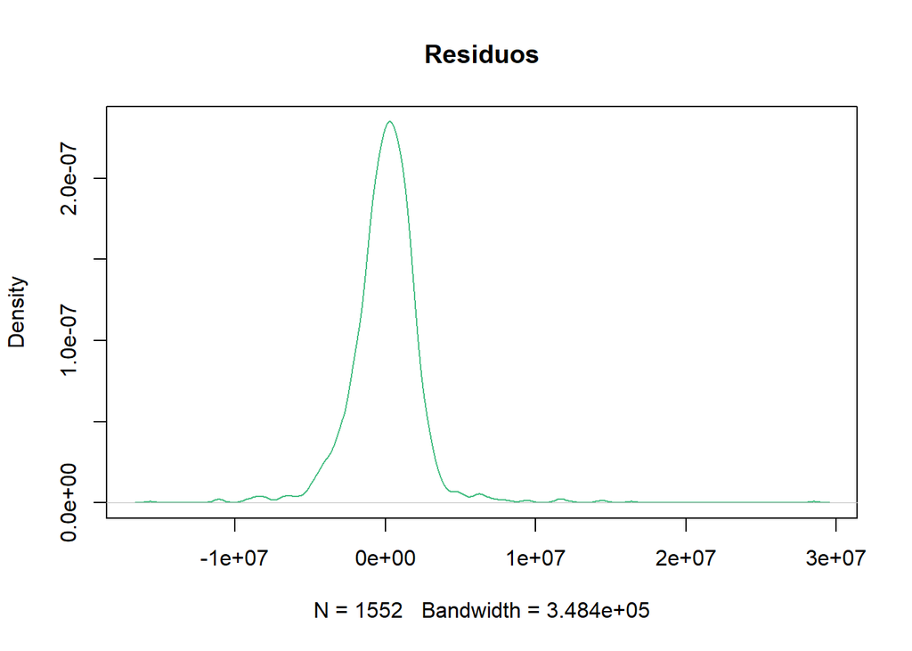

```r
plot(density(reg$residuals),col=colorPalett[2], main="Residuos", )
```

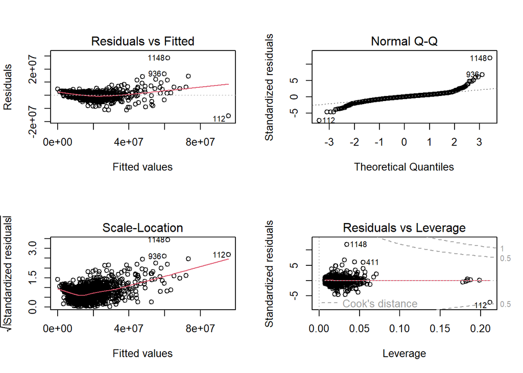

```r
par(mfrow = c(2,2))
plot(reg)
```

## Ejercicio 9

**Obtenga el valor del R2 de predicción en la muestra test.**

```r
pred = predict(reg, test)
predSSE = sum((test$Valor-pred)^2)
R2test = 1 - predSSE/(var(test$Valor)*(nrow(test)-1))
R2test
```

```
## [1] 0.9413005
```

El R2 de la muestra test (0.9413005) es casi igual al R2 de la muestra training (0.9437738) ya que ambas muestras han sido obtenidas de un mismo data set.

Si los datos de la muestra Test fueran de un data set diferente (e.g año siguente), probablemente se observaría un R2 con alguna diferencia.

## Ejercicio 10

**Obtenga el fichero con las predicciones del valor de las viviendas con su intervalo de confianza del 95%, para los pisos de la muestra test.**

```r
pred_conf = predict(reg, newdata=test, interval="confidence")
head(pred_conf,30)
```

```
##           fit      lwr      upr
## 1551 28925135 27793058 30057212
## 1552 10115547  9505246 10725849
## 1553 10039551  8998165 11080937
## 1554 16470184 15701641 17238727
## 1555 12104003 11500724 12707283
## 1556 17955868 17301426 18610310
## 1557 19289499 18144580 20434419
## 1558 26383079 25244493 27521665
## 1559 19835344 18886538 20784149
## 1560 22695180 22097313 23293046
## 1561 18845789 18295446 19396132
## 1562 11482529 10825965 12139093
## 1563 27222591 26693101 27752080
## 1564 16709673 15995159 17424188
```

[output cut: 16 more lines]